# Eval Lab

Helena Lindsay, Max St John, Allen Baiju

11/3/2020

## CNN Data

### Tree Based

#### Part 1

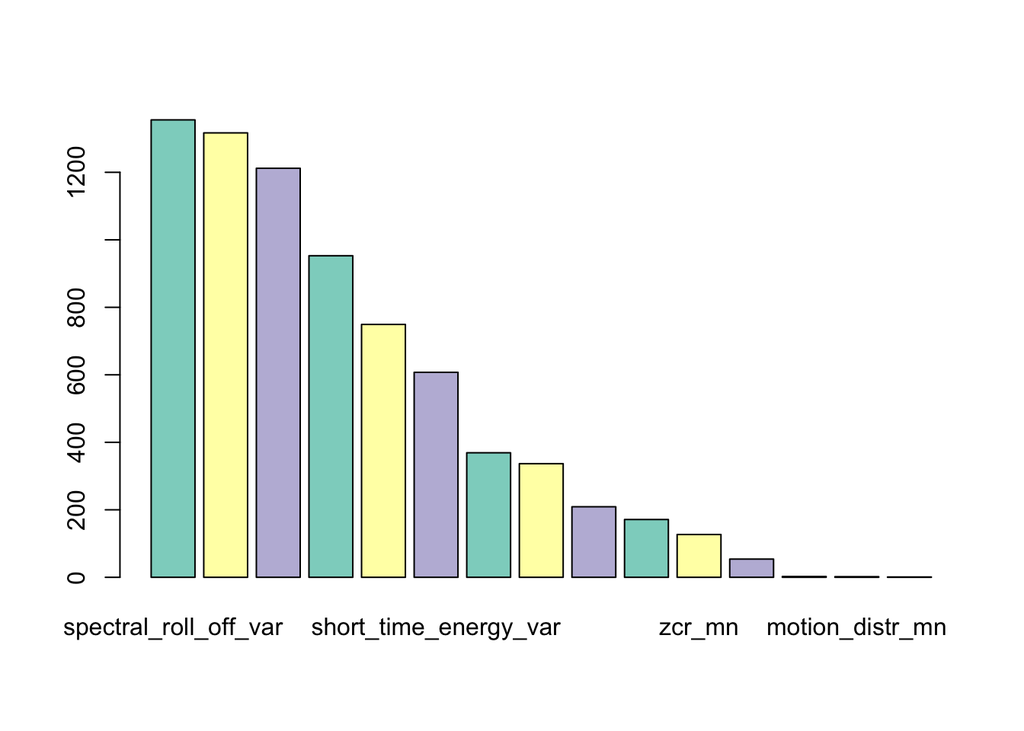

```r
library(RColorBrewer)
coul <- brewer.pal(3, "Set3")
barplot(CNN_train$finalModel$variable.importance, col=coul)
```

```r
confusionMatrix(CNN_eval, test_outcome, positive = "1", dnn=c("Prediction", "Actual"), mode = "sens_spec")
```

```
## Confusion Matrix and Statistics
##
##           Actual
## Prediction   -1    1
##         -1 1063  515
##         1   563 2367
##
##                Accuracy : 0.7609
##                  95% CI : (0.7481, 0.7733)
##     No Information Rate : 0.6393
##     P-Value [Acc > NIR] : <2e-16
##
##                   Kappa : 0.4781
##
##  Mcnemar's Test P-Value : 0.1523
##
##             Sensitivity : 0.8213
##             Specificity : 0.6538
##          Pos Pred Value : 0.8078
##          Neg Pred Value : 0.6736
##              Prevalence : 0.6393
##          Detection Rate : 0.5251
##    Detection Prevalence : 0.6500
##       Balanced Accuracy : 0.7375
##
##        'Positive' Class : 1
##
```

```r
baserate = table(CNNdata$label)[2] / sum(table(CNNdata$label))
baserate
```

```
##         1
## 0.6392105
```

From this confusion matrix, we can see that the Accuracy rate is 76.09%, which is 12.17% higher than the base rate. The Kappa of 47.81% would be classified as a moderate score. We got 82.13% and 65.38% for sensitivity (TPR) and specificity rates respectively.

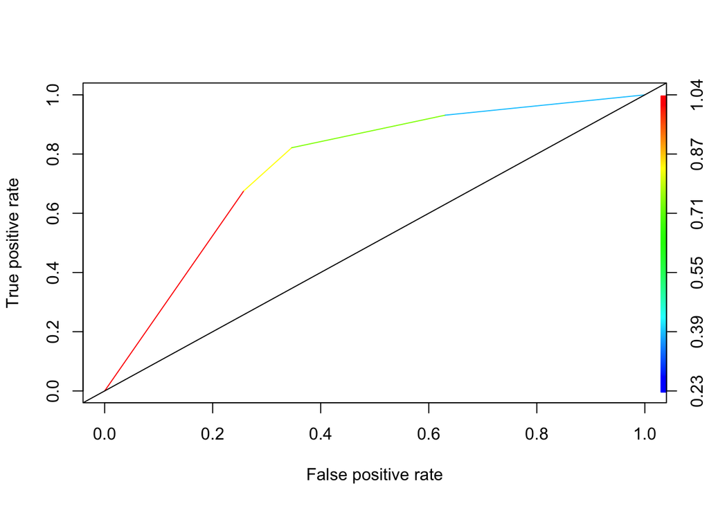

```
## integer(0)
```

```r
tree_perf_AUC <- performance(pred,"auc")

print(tree_perf_AUC@y.values)
```

```
## [[1]]
## [1] 0.7592936
```

Generally, AUC values between 0.7 and 0.8 are considered acceptable, 0.8 and 0.9 are considered excellent, and over 0.9 are considered outstanding. In our model, the AUC value of 0.7593 shows that the overall accuracy of the model is high enough.

#### Part 2

```
##
## Call:
## calibration.formula(x = test ~ pred_prob, data = CNN_eval)
##
## Models: pred_prob
## Event:  -1
## Cuts: 11
```

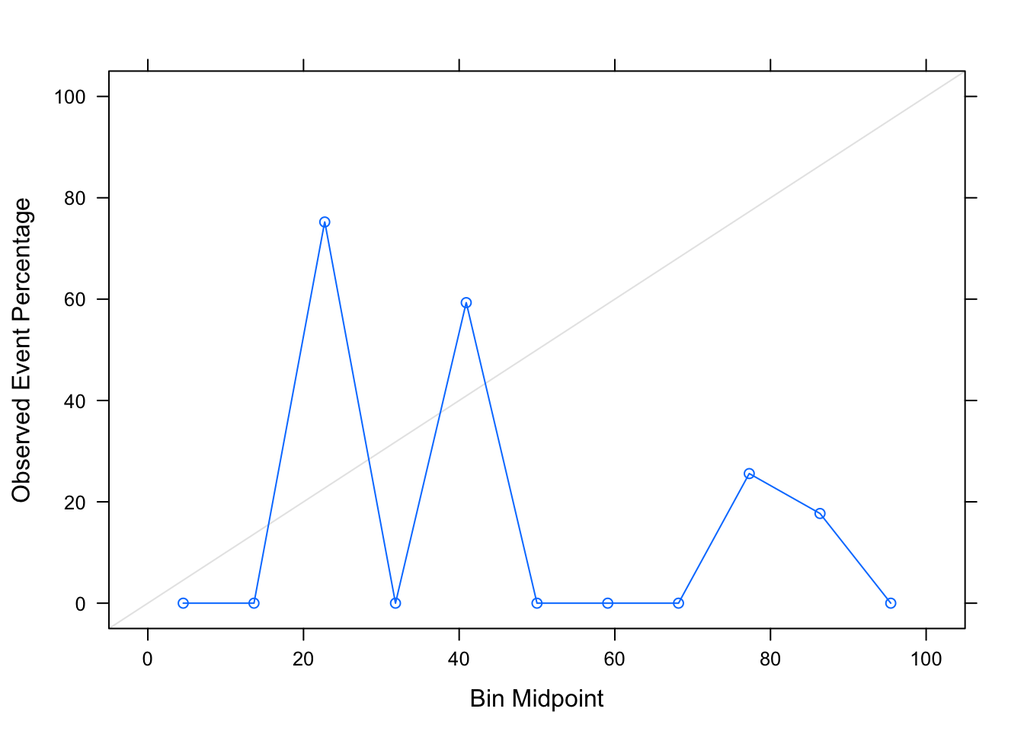

| test_var | pred_var | bias |
| --- | --- | --- |
| 0.2306445 | 0.2275638 | -0.0106477 |

```r
LogLoss3NN <- LogLoss(as.numeric(CNN_eval$pred_prob), as.numeric(CNN_eval$test))
LogLoss3NN
```

```
## [1] 0.5327108
```

Our bias of -0.0106 is close to 0 and thus we can say that there isn’t much bias in this model. The variance of our test outcomes was 0.2306 while our prediction variance was 0.2276. Considering that a good variance score is generally said to be over 60%, we should consider adding more data to improve our model. Since both the variances and bias are low, we should take into account the possibility of the model being overfit. The LogLoss value of 0.533 is far from 0, and can be further improved.

#### Part 3

|  | 0.1 | 0.2 | 0.3 | 0.4 | 0.5 | 0.6 | 0.7 | 0.8 | 0.9 |
| --- | --- | --- | --- | --- | --- | --- | --- | --- | --- |
| Accuracy | 0.6393079 | 0.6393079 | 0.7287045 | 0.7608696 | 0.7608696 | 0.7608696 | 0.7608696 | 0.6998669 | 0.3606921 |
| Kappa | 0.0000000 | 0.0000000 | 0.3384233 | 0.4781318 | 0.4781318 | 0.4781318 | 0.4781318 | 0.3912306 | 0.0000000 |
| Sensitivity | 1.0000000 | 1.0000000 | 0.9312977 | 0.8213046 | 0.8213046 | 0.8213046 | 0.8213046 | 0.6759195 | 0.0000000 |
| FPR | 0.3606921 | 0.3606921 | 0.2763548 | 0.1921502 | 0.1921502 | 0.1921502 | 0.1921502 | 0.1770173 | NaN |
| TPR | 1.0000000 | 1.0000000 | 0.9312977 | 0.8213046 | 0.8213046 | 0.8213046 | 0.8213046 | 0.6759195 | 0.0000000 |

When adjusting the threshold from 0.1 to 0.9, we can see that any threshold between 0.4 and 0.7 would provide us with the most balanced scores across all measures.

### KNN (3)

#### Part 1

```r
baserate = table(CNNdata$label)[2] / sum(table(CNNdata$label))
baserate
```

```
##         1
## 0.6392105
```

There are 14,411 commercials and 8,134 non-commercials. At random, we have a 63.9% chance of correctly picking out a commercial.

```r
commercial_correlations = cor(CNNdata2)
head(commercial_correlations)
```

```
##                      shot_length motion_distr_mn frame_diff_dist_mn
## shot_length           1.00000000    -0.147625726        -0.14921262
## motion_distr_mn      -0.14762573     1.000000000         0.71570313
## frame_diff_dist_mn   -0.14921262     0.715703132         1.00000000
## short_time_energy_mn  0.02648501    -0.007160132        -0.02396823
## zcr_mn                0.19090475    -0.052205970        -0.04207414
## spectral_centroid_mn  0.36441928    -0.179064774        -0.29891277
##                      short_time_energy_mn      zcr_mn spectral_centroid_mn
## shot_length                   0.026485006  0.19090475            0.3644193
## motion_distr_mn              -0.007160132 -0.05220597           -0.1790648
## frame_diff_dist_mn           -0.023968229 -0.04207414           -0.2989128
## short_time_energy_mn          1.000000000 -0.12505793            0.3087839
## zcr_mn                       -0.125057928  1.00000000            0.3089015
## spectral_centroid_mn          0.308783942  0.30890154            1.0000000
##                      spectral_roll_off_mn spectral_flux_mn fundamental_freq_mn
## shot_length                    0.38018472      0.102311184          0.29268568
## motion_distr_mn               -0.22152474     -0.019123107         -0.09698064
## frame_diff_dist_mn            -0.38483945      0.006196663         -0.09067221
## short_time_energy_mn           0.16031349      0.823463249          0.02251202
## zcr_mn                         0.03308083     -0.053369373          0.53355483
## spectral_centroid_mn           0.80926285      0.283419648          0.41901010
##                      motion_dist_mn       label
## shot_length              0.21214421 -0.27210692
## motion_distr_mn         -0.75764527  0.05393804
## frame_diff_dist_mn      -0.64517894 -0.04745652
## short_time_energy_mn     0.03141285  0.10881483
## zcr_mn                   0.06741515 -0.25376348
## spectral_centroid_mn     0.31396448 -0.27342595
```

Motion distribution is highly correlated with frame differential distribution and motion distribution with values of 0.715 and -0.757, respectively. Short time energy is highly correlated with spectral flux with a value of 0.823. Spectral centroid is highly correlated with spectral roll off with a value of 0.809.

```r
set.seed(1982)
library(class)
cl = train_data[, "label"]

commercials_3NN <-  knn(train = train_data,
               test = test,
               cl = train_data$label,
               k = 3,
               prob = TRUE)
```

```r
confusionMatrix(commercials_3NN, as.factor(test_outcome), positive = "1", dnn=c("Prediction", "Actual"), mode = "sens_spec")
```

```
## Confusion Matrix and Statistics
##
##           Actual
## Prediction   -1    1
##         -1 1554   72
##         1    68 2815
##
##                Accuracy : 0.969
##                  95% CI : (0.9635, 0.9738)
##     No Information Rate : 0.6403
##     P-Value [Acc > NIR] : <2e-16
##
##                   Kappa : 0.9326
##
##  Mcnemar's Test P-Value : 0.7998
##
##             Sensitivity : 0.9751
##             Specificity : 0.9581
##          Pos Pred Value : 0.9764
##          Neg Pred Value : 0.9557
##              Prevalence : 0.6403
##          Detection Rate : 0.6243
##    Detection Prevalence : 0.6394
##       Balanced Accuracy : 0.9666
##
##        'Positive' Class : 1
##
```

From this confusion matrix, we can see that the Accuracy rate is 96.9%, which is 32.8% higher than the base rate. The Kappa of 93.26% would be classified as a very good score. We got 97.51% and 95.81% for sensitivity (TPR) and specificity rates respectively.Just by looking at the confusion matrix, we should question the validity of the model, since all the measures seem very high.

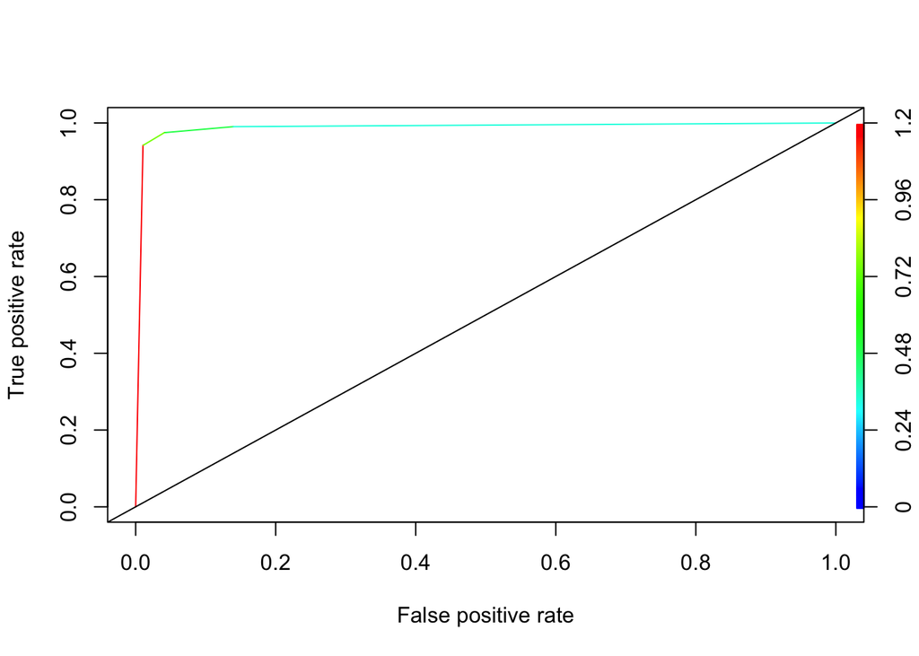

```
## integer(0)
```

```r
plot(tree_perf, colorize=TRUE) + abline(a=0, b= 1)
```

#### Part 2

```
##
## Call:
## calibration.formula(x = test ~ pred_prob, data = commercials_3NN)
##
## Models: pred_prob
## Event:  -1
## Cuts: 11
```

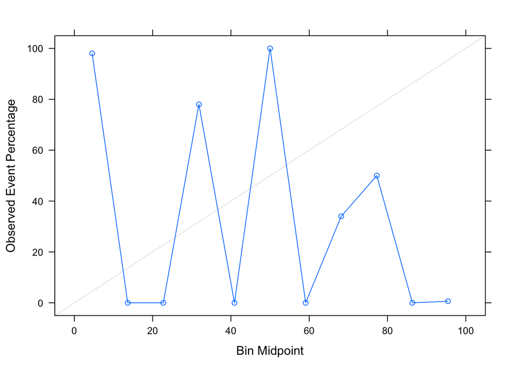

```
## [1] 0.0008871147
```

| test_var | pred_var | bias |
| --- | --- | --- |
| 0.230374 | 0.2306222 | 0.0008871 |

```r
LogLoss3NN <- LogLoss(as.numeric(commercials_3NN$pred_prob), as.numeric(commercials_3NN$test))
LogLoss3NN
```

```
## [1] 0.3907639
```

Our bias of 0.0008871 is close to 0 and thus we can say that there isn’t much bias in this model. The variance of our test outcomes was 0.2304 while our prediction variance was 0.2306. Considering that a good variance score is generally said to be over 60%, we should consider adding more data to improve our model. The LogLoss value of 0.39 is a relatively good score.

#### Part 3

|  | 0.1 | 0.2 | 0.3 | 0.4 | 0.5 | 0.6 | 0.7 | 0.8 | 0.9 |
| --- | --- | --- | --- | --- | --- | --- | --- | --- | --- |
| Accuracy | 0.9436682 | 0.9436682 | 0.9436682 | 0.9685074 | 0.9691728 | 0.9691728 | 0.9589709 | 0.9589709 | 0.9589709 |
| Kappa | 0.8743509 | 0.8743509 | 0.8743509 | 0.9316523 | 0.9331234 | 0.9331234 | 0.9126887 | 0.9127118 | 0.9127118 |
| Sensitivity | 0.9903014 | 0.9903014 | 0.9903014 | 0.9750606 | 0.9750606 | 0.9750606 | 0.9421545 | 0.9418081 | 0.9418081 |
| FPR | 0.0732577 | 0.0732577 | 0.0732577 | 0.0242634 | 0.0232477 | 0.0232477 | 0.0065741 | 0.0062135 | 0.0062135 |
| TPR | 0.9903014 | 0.9903014 | 0.9903014 | 0.9750606 | 0.9750606 | 0.9750606 | 0.9421545 | 0.9418081 | 0.9418081 |

When adjusting the threshold from 0.1 to 0.9, we can see that any threshold between 0.4 and 0.6 would provide us with the most balanced scores across all measures.

### KNN (11)

#### Part 1

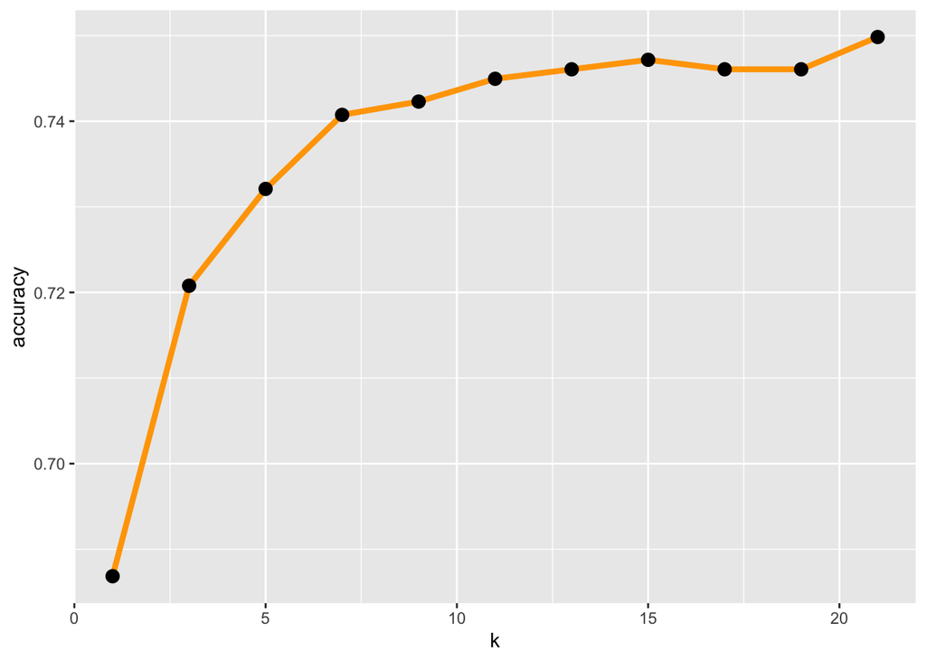

From the above elbow chart, we decided to use k=11 for further analysis.

```
## Confusion Matrix and Statistics
##
##           Actual
## Prediction   -1    1
##         -1 1469  111
##         1   153 2776
##
##                Accuracy : 0.9415
##                  95% CI : (0.9342, 0.9481)
##     No Information Rate : 0.6403
##     P-Value [Acc > NIR] : < 2e-16
##
##                   Kappa : 0.8722
##
##  Mcnemar's Test P-Value : 0.01162
##
##             Sensitivity : 0.9616
##             Specificity : 0.9057
##          Pos Pred Value : 0.9478
##          Neg Pred Value : 0.9297
##              Prevalence : 0.6403
##          Detection Rate : 0.6157
##    Detection Prevalence : 0.6496
##       Balanced Accuracy : 0.9336
##
##        'Positive' Class : 1
##
```

The k=11 model has a high accuracy rate of 94.15%, along with a strong kappa value of 87.22%. Sensitivity and specificity rates are both very good as well.

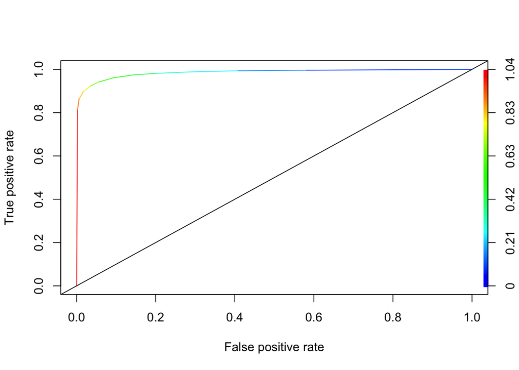

```
## integer(0)
```

```r
tree_perf_AUC <- performance(pred,"auc")

tree_perf_AUC@y.values
```

```
## [[1]]
## [1] 0.9846506
```

As seen in the ROC curve and the AUC value, this model seem to be able to classify with a very high classification accuracy. Although less extreme, similar to our k=3 model, this model should also be treated with regards to the possibility of over-fitting.

#### Part 2

```
##
## Call:
## calibration.formula(x = test ~ pred_prob, data = commercials_11NN)
##
## Models: pred_prob
## Event:  -1
## Cuts: 11
```

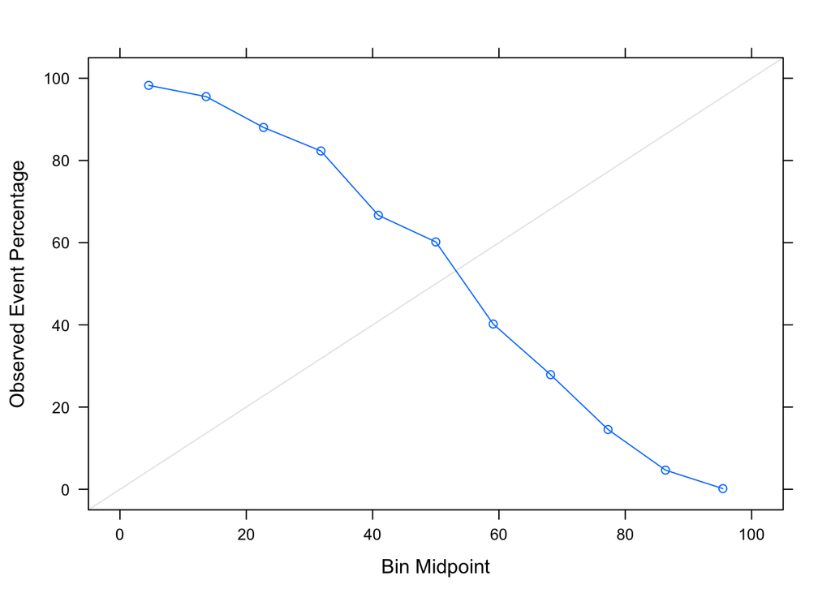

```
## [1] 0.9906853
```

| test_var | pred_var | bias |
| --- | --- | --- |
| 0.230374 | 0.2276734 | 0.9906853 |

```r
commercials_11NN$test <- recode(commercials_11NN$test, "-1"=0,"1"=1)
LogLoss11NN <- LogLoss(as.numeric(commercials_11NN$pred_prob), as.numeric(commercials_11NN$test))
LogLoss11NN
```

```
## [1] 0.2560797
```

Our bias of 0.99 can be closer to 0 and thus we believe that there is potential for this model to improve. The variance of our test outcomes was 0.23 while our prediction variance was 0.2277. Considering that a good variance score is generally said to be over 60%, we should consider adding more data to improve our model. The LogLoss value of 0.256 is a relatively good score.

#### Part 3

|  | 0.1 | 0.2 | 0.3 | 0.4 | 0.5 | 0.6 | 0.7 | 0.8 | 0.9 |
| --- | --- | --- | --- | --- | --- | --- | --- | --- | --- |
| Accuracy | 0.8478598 | 0.8875582 | 0.9157241 | 0.9319139 | 0.9414504 | 0.9427811 | 0.9379020 | 0.9274784 | 0.9108450 |
| Kappa | 0.6380436 | 0.7405177 | 0.8100705 | 0.8489504 | 0.8721716 | 0.8770148 | 0.8681847 | 0.8481642 | 0.8159528 |
| Sensitivity | 0.9934188 | 0.9882231 | 0.9812955 | 0.9743679 | 0.9615518 | 0.9425009 | 0.9224108 | 0.8960859 | 0.8642189 |
| FPR | 0.1886846 | 0.1422129 | 0.1031972 | 0.0764938 | 0.0522363 | 0.0327053 | 0.0205958 | 0.0103290 | 0.0039920 |
| TPR | 0.9934188 | 0.9882231 | 0.9812955 | 0.9743679 | 0.9615518 | 0.9425009 | 0.9224108 | 0.8960859 | 0.8642189 |

When adjusting the threshold from 0.1 to 0.9, we can see that any threshold between 0.5 and 0.6 would provide us with the most balanced scores across all measures.

## Loan Data

### Tree Based

#### Part 1

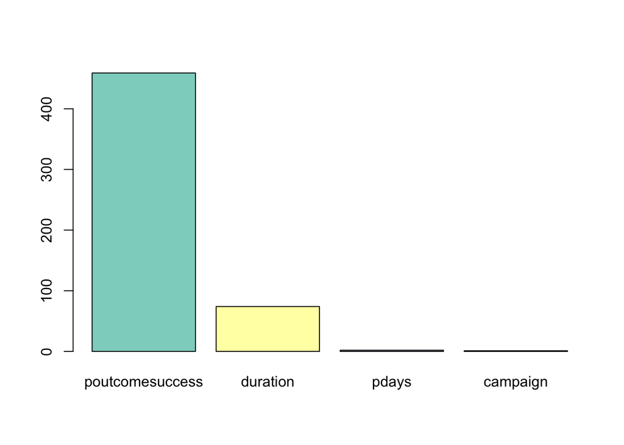

```
## Confusion Matrix and Statistics
##
##           Actual
## Prediction    0    1
##          0 1115  188
##          1   55  151
##
##                Accuracy : 0.839
##                  95% CI : (0.8194, 0.8572)
##     No Information Rate : 0.7753
##     P-Value [Acc > NIR] : 4.874e-10
##
##                   Kappa : 0.4629
##
##  Mcnemar's Test P-Value : < 2.2e-16
##
##             Sensitivity : 0.4454
##             Specificity : 0.9530
##          Pos Pred Value : 0.7330
##          Neg Pred Value : 0.8557
##              Prevalence : 0.2247
##          Detection Rate : 0.1001
##    Detection Prevalence : 0.1365
##       Balanced Accuracy : 0.6992
##
##        'Positive' Class : 1
##
```

From this confusion matrix, we can see that the Accuracy rate is 83.9%. The Kappa of 46.29% would be classified as a moderate score. The sensitivity (TPR) rate of 44.54% isn’t as high as we wanted it to be, but the specificity(TNR) rate of 95.3% is very high.

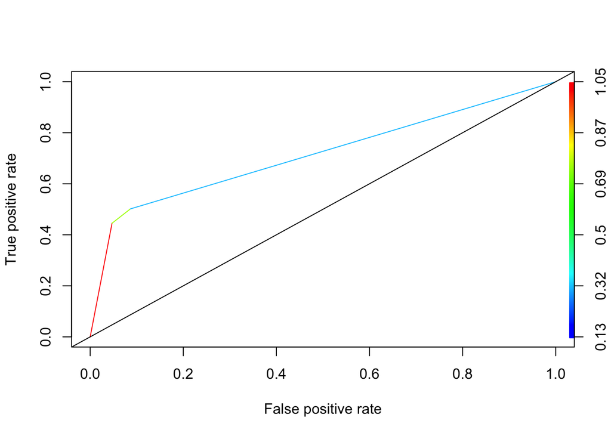

```
## integer(0)
```

```
## [[1]]
## [1] 0.715014
```

The AUC score of 0.715 would be considered a fair score, and we can most likely eliminate the possibility of the model being over-fitting or under-fitting in this case.

#### Part 2

```
##
## Call:
## calibration.formula(x = test ~ pred_prob, data = bank_eval)
##
## Models: pred_prob
## Event:  0
## Cuts: 11
```

```
## [1] 0.08813784
```

| test_var | pred_var | bias |
| --- | --- | --- |
| 0.174299 | 0.1179563 | 0.0881378 |

```r
LogLoss_bank <- LogLoss(as.numeric(bank_eval$pred_prob), as.numeric(bank_eval$test))
LogLoss_bank
```

```
## [1] 1.844982
```

The bias score of 0.088 is low enough to consider that this model is unbiased, but this model also suggests a low variance in both the test outcomes and predicted outcomes. The low variances suggest the possibility of over-fitting of this model. Our LogLoss of 1.845 is very high, and can be improved as well.

#### Part 3

```r
thresholds <- seq(.1, .9, .1)
metrics <- data.frame(sapply(thresholds, function(x) adjust_thres(bank_eval_prob$`1`,x, test_outcome)$overall))
sensitivity <- sapply(thresholds, function(x) adjust_thres(bank_eval_prob$`1`,x, test_outcome)$byClass[1])
results <- lapply(thresholds, function(x) adjust_thres(bank_eval_prob$`1`,x, test_outcome)$table)
FPR.list <- sapply(results, function(x) x[2,1]/(x[2,1]+x[2,2]))
TPR.list <- sapply(results, function(x) x[2,2]/(x[1,2]+x[2,2]))
metrics <- rbind(metrics, sensitivity, FPR.list, TPR.list)
metrics <- metrics[-c(3:7),]
rownames(metrics) <- c("Accuracy", "Kappa", "Sensitivity", "FPR", "TPR")
colnames(metrics) <- thresholds
kable(metrics, format = "markdown")
```

|  | 0.1 | 0.2 | 0.3 | 0.4 | 0.5 | 0.6 | 0.7 | 0.8 | 0.9 |
| --- | --- | --- | --- | --- | --- | --- | --- | --- | --- |
| Accuracy | 0.2246521 | 0.8210736 | 0.8210736 | 0.8389662 | 0.8389662 | 0.8389662 | 0.8389662 | 0.7753479 | 0.7753479 |
| Kappa | 0.0000000 | 0.4469917 | 0.4469917 | 0.4629162 | 0.4629162 | 0.4629162 | 0.4629162 | 0.0000000 | 0.0000000 |
| Sensitivity | 1.0000000 | 0.5014749 | 0.5014749 | 0.4454277 | 0.4454277 | 0.4454277 | 0.4454277 | 0.0000000 | 0.0000000 |
| FPR | 0.7753479 | 0.3726937 | 0.3726937 | 0.2669903 | 0.2669903 | 0.2669903 | 0.2669903 | NaN | NaN |
| TPR | 1.0000000 | 0.5014749 | 0.5014749 | 0.4454277 | 0.4454277 | 0.4454277 | 0.4454277 | 0.0000000 | 0.0000000 |

When adjusting the threshold from 0.1 to 0.9, we can see that any threshold between 0.2 and 0.3 would provide us with the most balanced scores across all measures.

### KNN (3)

#### Part 1

```r
confusionMatrix(bank_3NN, as.factor(test_outcome), positive = "1", dnn=c("Prediction", "Actual"), mode = "sens_spec")
```

```
## Confusion Matrix and Statistics
##
##           Actual
## Prediction    0    1
##          0 7290  780
##          1  402  254
##
##                Accuracy : 0.8645
##                  95% CI : (0.8572, 0.8717)
##     No Information Rate : 0.8815
##     P-Value [Acc > NIR] : 1
##
##                   Kappa : 0.2297
##
##  Mcnemar's Test P-Value : <2e-16
##
##             Sensitivity : 0.24565
##             Specificity : 0.94774
##          Pos Pred Value : 0.38720
##          Neg Pred Value : 0.90335
##              Prevalence : 0.11850
##          Detection Rate : 0.02911
##    Detection Prevalence : 0.07518
##       Balanced Accuracy : 0.59669
##
##        'Positive' Class : 1
##
```

This model has a good accuracy rate of 86.45%, but has a very low kappa score of 0.2297. It also has a low sensitivity rate of 24.565% with a high specificity rate of 94.77%.

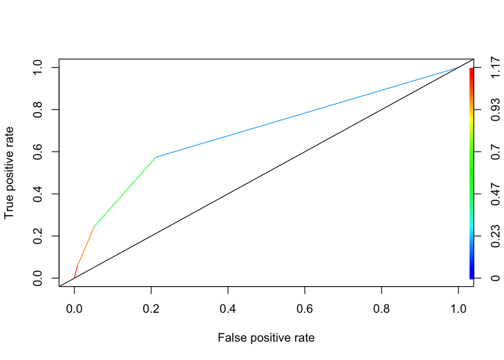

```
## integer(0)
```

```r
plot(tree_perf, colorize=TRUE) + abline(a=0, b= 1)
```

```r
tree_perf_AUC <- performance(pred,"auc")

tree_perf_AUC@y.values
```

```
## [[1]]
## [1] 0.6926447
```

The AUC of 0.6926 isn’t too good, and suggests that the model doesn’t perform well in classifying data.

#### Part 2

```
##
## Call:
## calibration.formula(x = test ~ pred_prob, data = bank_3NN)
##
## Models: pred_prob
## Event:  0
## Cuts: 11
```

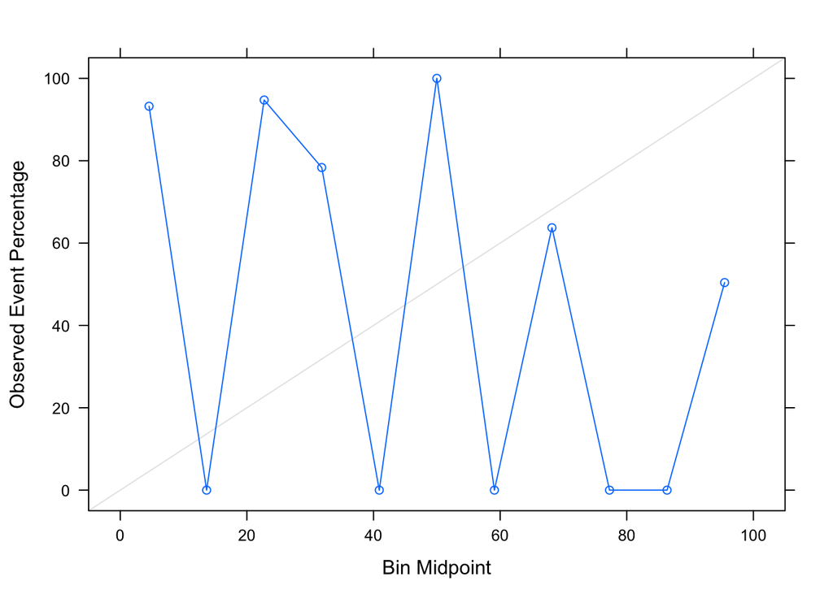

```
## [1] 0.04331882
```

| test_var | pred_var | bias |
| --- | --- | --- |
| 0.104467 | 0.0695339 | 0.0433188 |

```r
LogLoss3NN <- LogLoss(as.numeric(bank_3NN$pred_prob), as.numeric(bank_3NN$test))
LogLoss3NN
```

```
## [1] 27.38628
```

Although this model has a low bias score, the variance for the test outcomes and prediction outcomes are very low, and thus suggests that this model may have a high bias. Our LogLoss was overwhelmingly high.

#### Part 3

|  | 0.1 | 0.2 | 0.3 | 0.4 | 0.5 | 0.6 | 0.7 | 0.8 | 0.9 |
| --- | --- | --- | --- | --- | --- | --- | --- | --- | --- |
| Accuracy | 0.7606005 | 0.7609443 | 0.7625487 | 0.8645427 | 0.8646573 | 0.8646573 | 0.8813890 | 0.8813890 | 0.8813890 |
| Kappa | 0.2395205 | 0.2399793 | 0.2417072 | 0.2297329 | 0.2300017 | 0.2300017 | 0.0823247 | 0.0823247 | 0.0823247 |
| Sensitivity | 0.5754352 | 0.5754352 | 0.5744681 | 0.2456480 | 0.2456480 | 0.2456480 | 0.0589942 | 0.0589942 | 0.0589942 |
| FPR | 0.7349666 | 0.7346120 | 0.7331536 | 0.6128049 | 0.6122137 | 0.6122137 | 0.5040650 | 0.5040650 | 0.5040650 |
| TPR | 0.5754352 | 0.5754352 | 0.5744681 | 0.2456480 | 0.2456480 | 0.2456480 | 0.0589942 | 0.0589942 | 0.0589942 |

### KNN (11)

#### Part 1

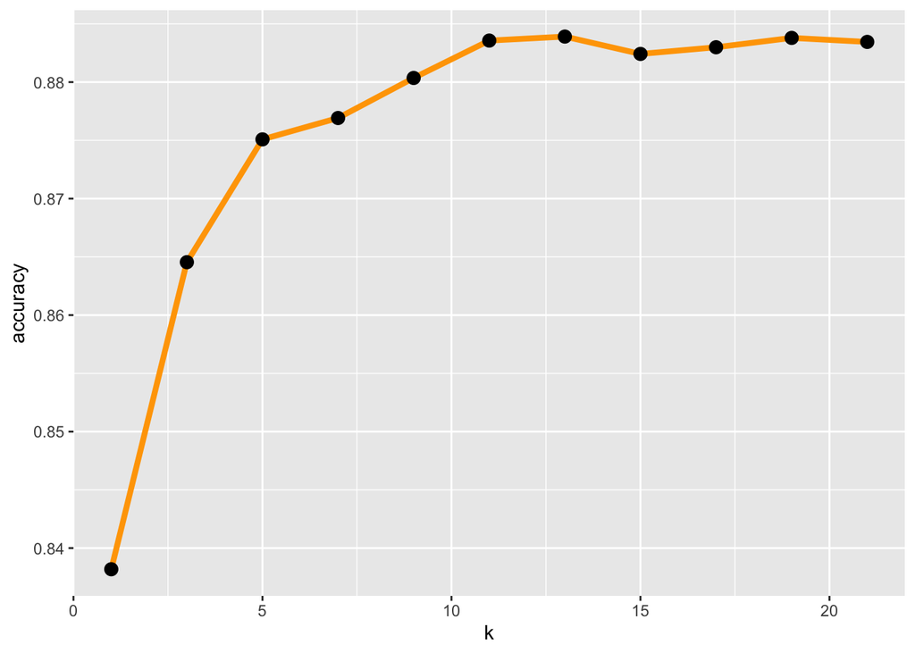

From the elbow chart, we decided to use k=11 for further analysis.

```r
bank_data_train_rows = sample(1:nrow(bank_data), round(0.8*nrow(bank_data)), replace = FALSE)
bank_data_train = bank_data[bank_data_train_rows, ]
bank_data_test = bank_data[-bank_data_train_rows, ]
bank_11NN <- knn(train = bank_data_train[, c("age", "duration", "balance")],
                test = bank_data_test[, c("age", "duration", "balance")],
                cl = bank_data_train[,"signed up"],
                k = 11,
                use.all = TRUE,
                prob = TRUE)
```

```r
prob_knn <- tibble(bank_11NN, attributes(bank_11NN)$prob)
prob_knn$prob <- if_else(prob_knn$bank_11NN==0,1-prob_knn$`attributes(bank_11NN)$prob`, prob_knn$`attributes(bank_11NN)$prob`)

test_outcome = as.factor(bank_data_test$`signed up`)

prob_knn$test <- test_outcome
```

```r
confusionMatrix(bank_11NN, as.factor(test_outcome), positive = "1", dnn=c("Prediction", "Actual"), mode = "sens_spec")
```

```
## Confusion Matrix and Statistics
##
##           Actual
## Prediction    0    1
##          0 7580  748
##          1  196  202
##
##                Accuracy : 0.8918
##                  95% CI : (0.8851, 0.8983)
##     No Information Rate : 0.8911
##     P-Value [Acc > NIR] : 0.4267
##
##                   Kappa : 0.2516
##
##  Mcnemar's Test P-Value : <2e-16
##
##             Sensitivity : 0.21263
##             Specificity : 0.97479
##          Pos Pred Value : 0.50754
##          Neg Pred Value : 0.91018
##              Prevalence : 0.10887
##          Detection Rate : 0.02315
##    Detection Prevalence : 0.04561
##       Balanced Accuracy : 0.59371
##
##        'Positive' Class : 1
##
```

Similar to our k=3 model, this model also has a solid accuracy rate but with a low kappa score of 0.2516. The specificity rate is higher than the sensitivity rate for this model as well. The balanced accuracy rate of 59.37% isn’t as high as we hoped it to be.

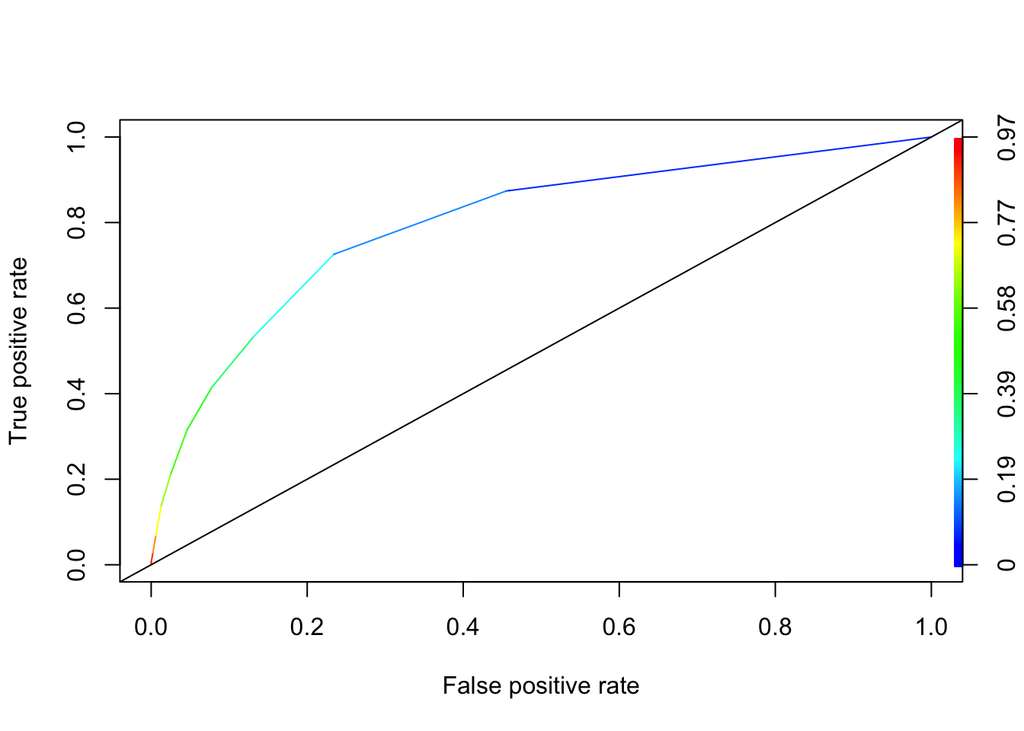

```
## integer(0)
```

```r
plot(tree_perf, colorize=TRUE) + abline(a=0, b= 1)
```

```r
tree_perf_AUC <- performance(pred,"auc")

tree_perf_AUC@y.values
```

```
## [[1]]
## [1] 0.7975404
```

The AUC value for this model is not bad with a 0.7975 score.

#### Part 2

```
##
## Call:
## calibration.formula(x = test ~ pred_prob, data = bank_11NN)
##
## Models: pred_prob
## Event:  0
## Cuts: 11
```

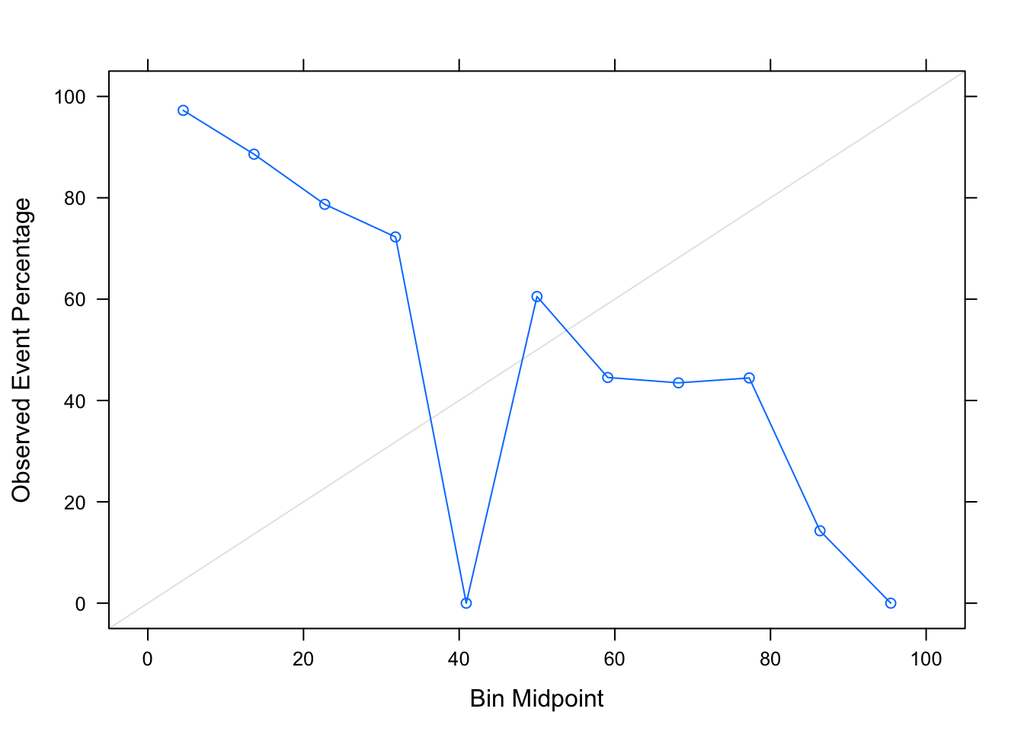

```
## [1] 0.06325923
```

| test_var | pred_var | bias |
| --- | --- | --- |
| 0.0970285 | 0.0435355 | 0.0632592 |

```r
LogLoss11NN <- LogLoss(as.numeric(bank_11NN$pred_prob), as.numeric(bank_11NN$test))
LogLoss11NN
```

```
## [1] 18.5355
```

This model also has a low bias score but low variance scores for both test outcomes and prediction outcomes. This suggests the model being highly biased. The LogLoss score of 18.54 also have room for improvement.

#### Part 3

|  | 0.1 | 0.2 | 0.3 | 0.4 | 0.5 | 0.6 | 0.7 | 0.8 | 0.9 |
| --- | --- | --- | --- | --- | --- | --- | --- | --- | --- |
| Accuracy | 0.7608297 | 0.8324547 | 0.8670639 | 0.8843686 | 0.8918176 | 0.8946826 | 0.8931928 | 0.8921614 | 0.8917030 |
| Kappa | 0.2850164 | 0.3175126 | 0.3297492 | 0.3115021 | 0.2515893 | 0.1872306 | 0.1017847 | 0.0433464 | 0.0109640 |
| Sensitivity | 0.7263158 | 0.5326316 | 0.4147368 | 0.3157895 | 0.2126316 | 0.1378947 | 0.0684211 | 0.0273684 | 0.0063158 |
| FPR | 0.7258641 | 0.6679790 | 0.6052104 | 0.5447648 | 0.4924623 | 0.4329004 | 0.4196429 | 0.3953488 | 0.1428571 |
| TPR | 0.7263158 | 0.5326316 | 0.4147368 | 0.3157895 | 0.2126316 | 0.1378947 | 0.0684211 | 0.0273684 | 0.0063158 |

A threshold between 0.2 and 0.3 would allow this model to perform at it’s maximum capacity.

# Conclusion